dose stratum

personyears

cases

HR (95% CI)

p.value

atc_group: A01 (stomatological preparations)

no use

41,961,553

15,611

1.0 (ref)

>2 prescr.

3,532

0

4.6e-05 (1.1e-90-2e+81)

9.20e-01

25th percentile

164,415

103

1.2 (0.97-1.4)

9.30e-02

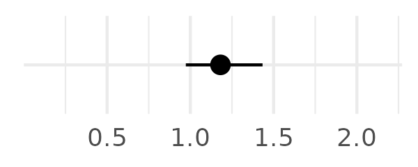

50th percentile

93,435

66

1.2 (0.97-1.6)

9.30e-02

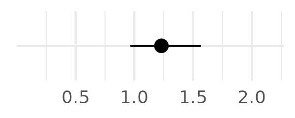

75th percentile

49,585

42

1.4 (1-1.9)

3.80e-02

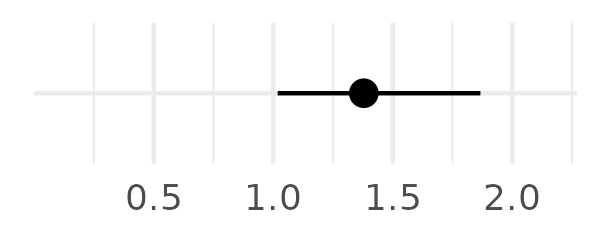

90th percentile

20,295

18

1.5 (0.93-2.3)

1.00e-01

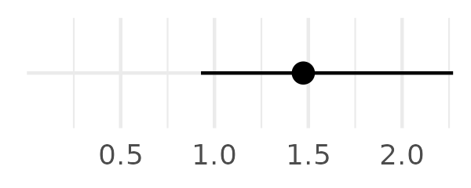

atc_group: A02 (drugs for acid related disorders)

no use

35,906,365

12,136

1.0 (ref)

>2 prescr.

1,280,651

542

0.98 (0.89-1.1)

5.70e-01

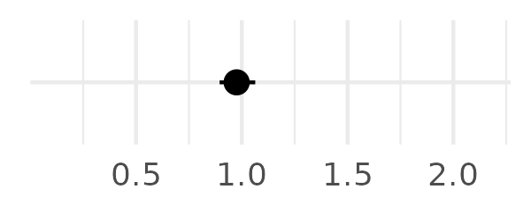

25th percentile

2,185,808

1,265

1.2 (1.1-1.3)

1.50e-09

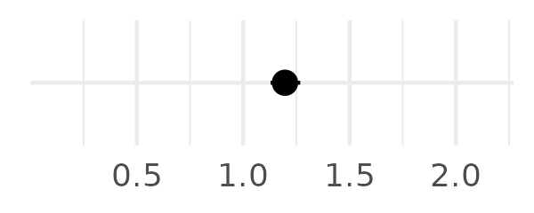

50th percentile

1,839,907

1,204

1.1 (1.1-1.2)

1.60e-04

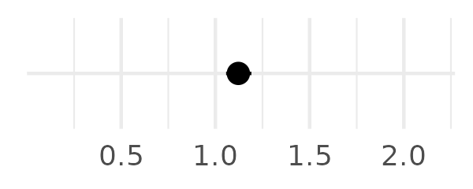

75th percentile

819,954

529

0.96 (0.88-1.1)

4.20e-01

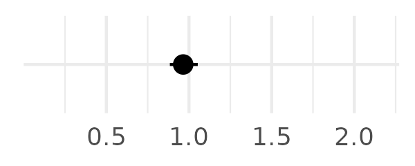

90th percentile

260,129

164

0.92 (0.79-1.1)

2.90e-01

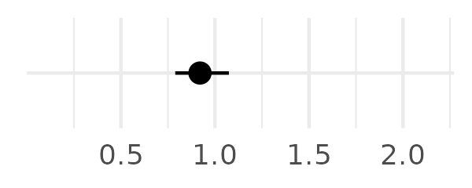

atc_group: A03 (drugs for functional gastrointestinal disorders)

no use

41,289,868

15,256

1.0 (ref)

>2 prescr.

7,597

0

1.8e-05 (3.4e-102-9.4e+91)

9.20e-01

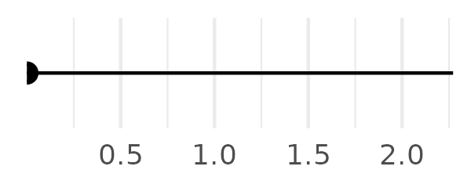

25th percentile

463,399

228

1.1 (0.95-1.2)

2.20e-01

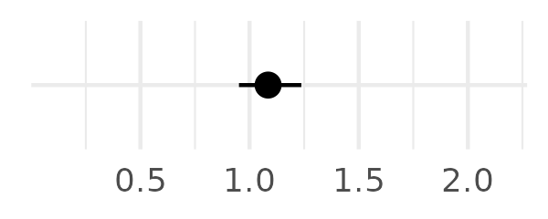

50th percentile

283,205

175

1.3 (1.1-1.5)

4.40e-04

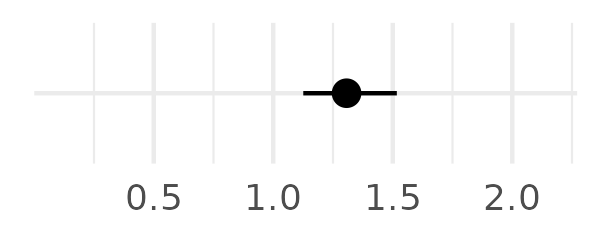

75th percentile

172,072

117

1.4 (1.1-1.6)

7.70e-04

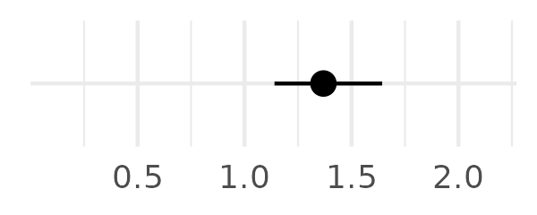

90th percentile

76,673

64

1.7 (1.3-2.2)

3.20e-05

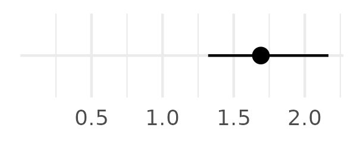

atc_group: A06 (drugs for constipation)

no use

41,746,574

15,218

1.0 (ref)

>2 prescr.

7,456

0

1.7e-05 (1.1e-94-2.6e+84)

9.20e-01

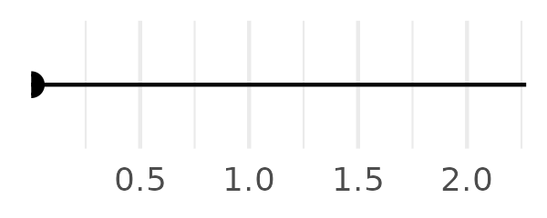

25th percentile

268,070

323

1.7 (1.5-1.9)

8.50e-20

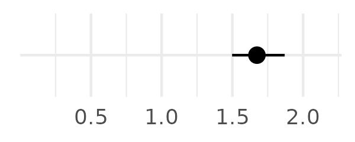

50th percentile

141,029

187

1.8 (1.6-2.1)

3.70e-16

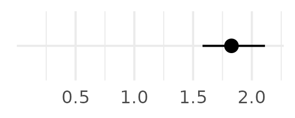

75th percentile

80,286

81

1.5 (1.2-1.8)

6.10e-04

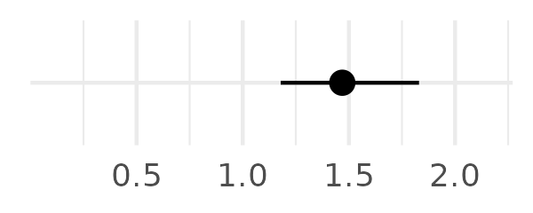

90th percentile

49,399

31

1 (0.71-1.4)

9.20e-01

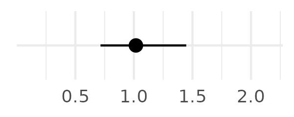

atc_group: A11 (vitamins)

no use

40,125,099

14,318

1.0 (ref)

>2 prescr.

583,103

333

1.3 (1.1-1.4)

5.40e-05

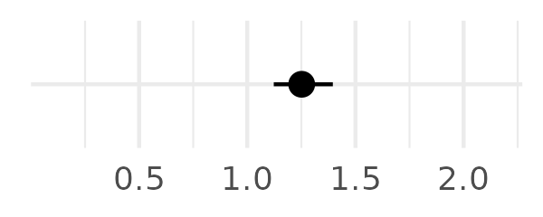

25th percentile

512,545

370

1.4 (1.2-1.5)

1.00e-09

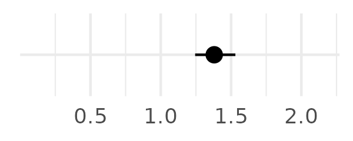

50th percentile

632,256

528

1.3 (1.2-1.5)

4.00e-11

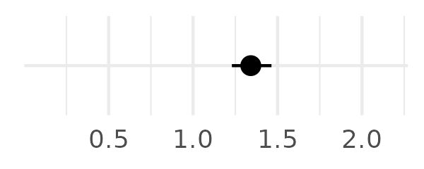

75th percentile

313,084

239

1 (0.92-1.2)

4.90e-01

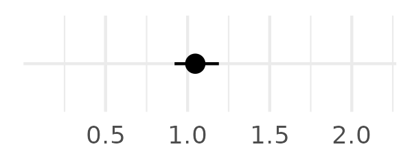

90th percentile

126,728

52

0.56 (0.43-0.74)

3.80e-05

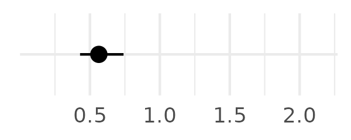

atc_group: A12 (mineral supplements)

no use

40,208,012

14,247

1.0 (ref)

>2 prescr.

540,251

389

1.2 (1.1-1.3)

4.10e-04

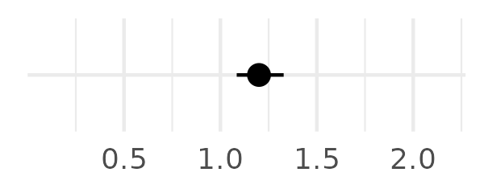

25th percentile

626,885

539

1.3 (1.2-1.4)

1.70e-10

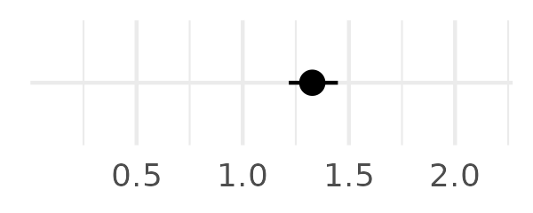

50th percentile

545,576

427

1.1 (1-1.3)

7.30e-03

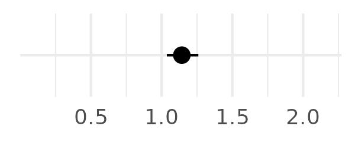

75th percentile

258,517

164

0.88 (0.76-1)

1.10e-01

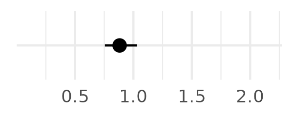

90th percentile

113,573

74

0.93 (0.73-1.2)

5.10e-01

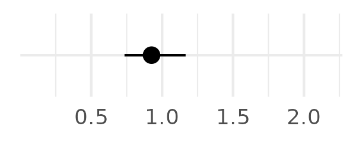

atc_group: B01 (antithrombotic agents)

no use

34,650,302

8,827

1.0 (ref)

>2 prescr.

2,129,634

1,860

1.3 (1.3-1.4)

5.00e-30

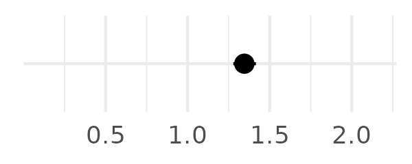

25th percentile

2,646,001

2,474

1.2 (1.2-1.3)

2.70e-15

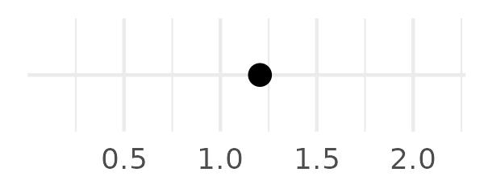

50th percentile

2,062,564

2,009

1.1 (1.1-1.2)

3.80e-05

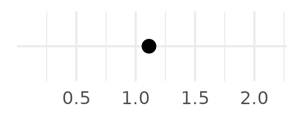

75th percentile

599,070

526

0.92 (0.84-1)

5.30e-02

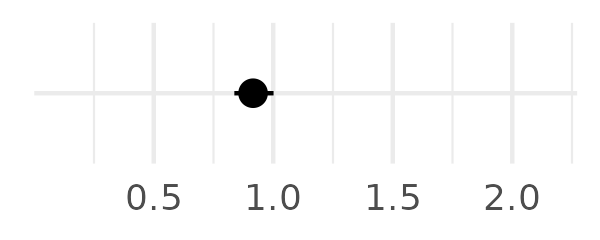

90th percentile

205,244

144

0.83 (0.7-0.98)

2.50e-02

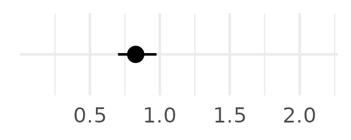

atc_group: B03 (antianemic preparations)

no use

39,710,443

14,126

1.0 (ref)

>2 prescr.

658,883

452

1.3 (1.2-1.4)

6.60e-08

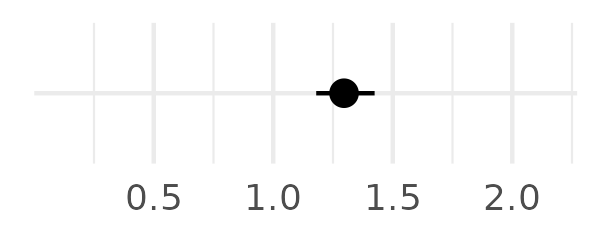

25th percentile

857,919

616

1.3 (1.2-1.4)

8.20e-08

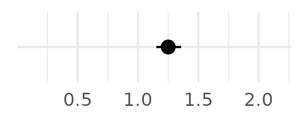

50th percentile

566,786

369

1.1 (0.97-1.2)

1.90e-01

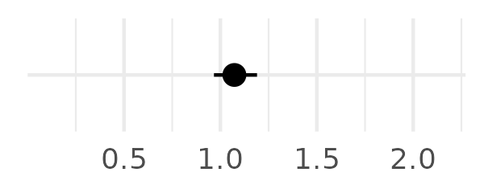

75th percentile

332,957

190

0.91 (0.78-1)

1.80e-01

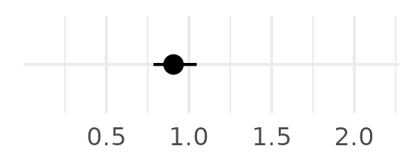

90th percentile

165,828

87

0.76 (0.62-0.94)

1.20e-02

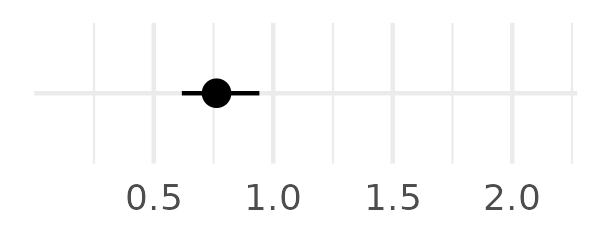

atc_group: C01 (cardiac therapy)

no use

40,086,414

13,679

1.0 (ref)

>2 prescr.

464,666

420

1.2 (1.1-1.3)

8.70e-04

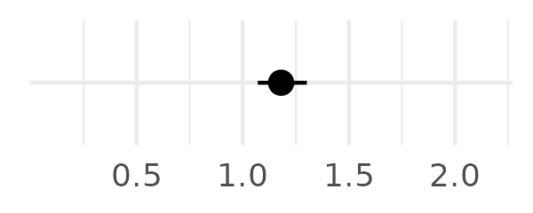

25th percentile

756,000

720

1.2 (1.1-1.3)

8.00e-05

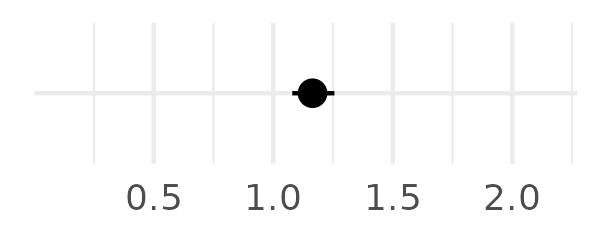

50th percentile

588,008

642

1.2 (1.1-1.3)

3.20e-06

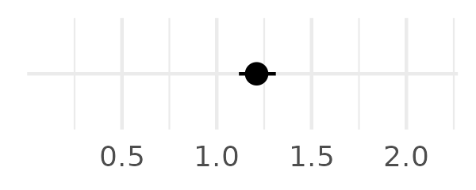

75th percentile

285,167

300

1.1 (1-1.3)

2.70e-02

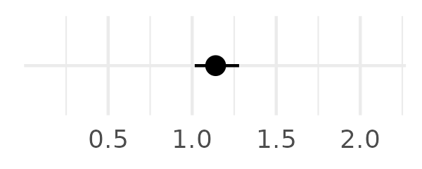

90th percentile

112,560

79

0.84 (0.68-1.1)

1.30e-01

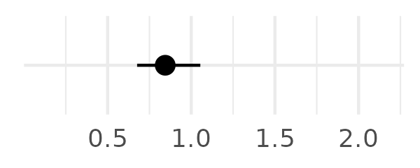

atc_group: C07 (beta blocking agents)

no use

36,167,406

10,486

1.0 (ref)

>2 prescr.

1,698,829

1,572

1.5 (1.4-1.6)

1.80e-54

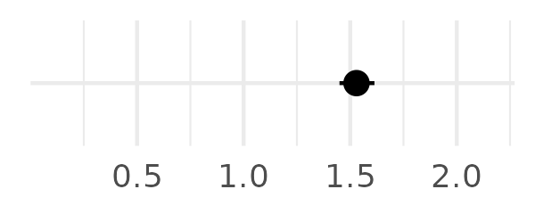

25th percentile

2,132,260

1,876

1.2 (1.2-1.3)

3.50e-15

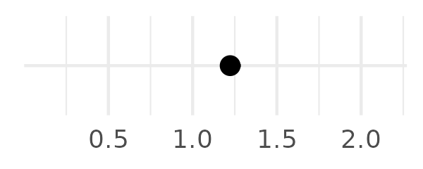

50th percentile

1,675,625

1,418

1 (0.99-1.1)